# Case study 3

Tran Thanh Hoa

12-13-2025

# **1. Introduction**

The dataset is sourced from [Customer Personality Analysis](https://www.kaggle.com/datasets/imakash3011/customer-personality-analysis) provided by **Dr.Omar Romero - Hernandez** and simulated business situations from a company trading various products (alcohol, meat, fish, etc.).

This project identifies customer segments and explores customer behaviors to support the optimization of marketing and sales strategies based on data.

## 1.1 Business Context

However, previous marketing campaigns were launched simultaneously for the entire customer base, leading to:

- High marketing costs
- Low response rate (acceptance rate)..
- Difficult to optimize products and sales channels for each customer group.

The leadership team wants to use data to **gain a clear understanding of ideal customers** and **identify high-value customer segments**.

## 1.2 Business Task

*Identify and analyze customer segments based on demographics, shopping behavior, and marketing feedback to optimize marketing strategies and allocate sales resources effectively.*

Elaboration:

- Which customers bring the highest value to the company?
- What are their behavioral and demographic characteristics?
- Which customer groups are likely to respond well to campaigns and promotions?
- Should we continue mass marketing or switch to targeted marketing by segment?

## 1.3 Business Questions

**Questions to be answered:**

1. Customers can be divided into segments based on:
- Demographics (Salary, Age, Education, …).
- Spending behavior by product category.
- Purchase channel (Web/store/Catalog).
2. Which customer groups:
- Spend the most?
- Purchase most frequently?
- Are least sensitive to promotions?
3. Which factors have the strongest impact on:
- Which customers respond to Marketing campaigns (Response, AcceptedCMP1-5)?
4. Which purchase channels are most effective for each customer segment?

## 1.4 Metrics

The indicators created or available in the data are intended to serve the purpose of analysis, combining variables and factors to make decisions.

**Customer value group**

- Total Spending.
- Recency.
- Purchase Frequency: NumWebPurchases, NumStorePurchases, NumCagtalogPurchases.

**Marketing group**

- Campaign Acceptance Rate
- Response Rate (last campaign)
- Deal Dependency: NumDealsPurchases/Total Purchases

**Sales channel group**

- Purchase proportion by each channel.
- Number of website visits vs number of purchases (Conversion proxy).

## 1.5 STAKEHOLDERS

**Marketing Manager**

- Want to know which customer group to **target the campaign at**.
- Interested in the promotion acceptance rate and response behavior.

**Sale Manager**

- Focus on **effective sales channels**.
- Want to allocate resources between Store / Web / Catalog.

**Product Manager**

- Want to understand **which customer groups are suitable for each type of product**.
- Use insights to develop new products.

## 1.6 Business Requirement

**Mandatory Requirements**

- Clear customer segmentation that can be explained.
- Insights must be: Actionable, Able to answer marketing questions.

**Optional Requirements (nice-to-have)**

- Compare behaviors between customers with and without children.
- Analyze loyalty based on Recency + Frequency.
- Propose personalized marketing strategies.

## 1.7 Deliverables

Analysis report (R Markdown -> HTML).

Charts:

- Customer segments.
- Spending patterns.
- Campaign response.

List of recommendations:

- Groups to prioritize for marketing.
- Groups to reduce acquisition costs.
- Suggested suitable marketing channels.

# **2. Prepare**

## 2.1 Data Sources

The data used in this project is a set [Customer Personal Analysis](https://www.kaggle.com/datasets/imakash3011/customer-personality-analysis), including information about:

- Customer demographics.
- Shopping behavior by product category.
- Feedback on marketing campaigns.
- Purchase channels and level of online engagement.

The dataset reflects customer behavior over a **2-year period**, long enough to observe spending trends and marketing responses.

## 2.2 Data Structure

The data is organized at the level of **one row per unique customer**, including:

- Personal information (age, income, marital status, etc.).
- Total spending by product category.
- Number of purchases by channel.
- Variables reflecting marketing behavior and loyalty.

This structure is suitable for:

- Customer value analysis.
- Customer segmentation.
- Campaign response behavior analysis.

## 2.4 Data limitations and risks

These limitations are noted to avoid overinterpretation when making recommendations:

- There is no data on profits or marketing costs.
- It does not reflect customer behavior after the data collection.
- Some demographic variables may be missing or outdated.

# **3. Process**

## 3.1 Data Cleaning Strategy

The goal of the data processing step is to ensure:

- Each customer is represented exactly once.
- Variables are comparable and analyzable.
- There is no significant bias due to erroneous or missing data, or outliers.

## 3.2 Data Cleaning Steps

The packages used for this analysis are:

- `tidyverse`
- `lubridate`
- `ggplot2`
- `skimr`
- `Janitor`
- `knitr`
- `dplyr`
- `gridExtra`

Proceed to read the dataset for analysis:

```r
dataframe <- read.table('C:/Users/Admin/Downloads/marketing_campaign.csv',sep = "\t", header = T)
```

Preview dataset:

```r
glimpse(dataframe)
```

```
Rows: 2,240
Columns: 29
$ ID                  <int> 5524, 2174, 4141, 6182, 5324, 7446, 965, 6177, 485…
$ Year_Birth          <int> 1957, 1954, 1965, 1984, 1981, 1967, 1971, 1985, 19…
$ Education           <chr> "Graduation", "Graduation", "Graduation", "Graduat…
$ Marital_Status      <chr> "Single", "Single", "Together", "Together", "Marri…
$ Income              <int> 58138, 46344, 71613, 26646, 58293, 62513, 55635, 3…
$ Kidhome             <int> 0, 1, 0, 1, 1, 0, 0, 1, 1, 1, 1, 0, 0, 1, 0, 0, 1,…
$ Teenhome            <int> 0, 1, 0, 0, 0, 1, 1, 0, 0, 1, 0, 0, 0, 1, 0, 0, 1,…
$ Dt_Customer         <chr> "04-09-2012", "08-03-2014", "21-08-2013", "10-02-2…
$ Recency             <int> 58, 38, 26, 26, 94, 16, 34, 32, 19, 68, 11, 59, 82…
$ MntWines            <int> 635, 11, 426, 11, 173, 520, 235, 76, 14, 28, 5, 6,…
$ MntFruits           <int> 88, 1, 49, 4, 43, 42, 65, 10, 0, 0, 5, 16, 61, 2, …
$ MntMeatProducts     <int> 546, 6, 127, 20, 118, 98, 164, 56, 24, 6, 6, 11, 4…
$ MntFishProducts     <int> 172, 2, 111, 10, 46, 0, 50, 3, 3, 1, 0, 11, 225, 3…
```

[output cut: 16 more lines]

### 3.2.1 Missing value & Duplicate

Check whether the data is duplicated, ensuring that every observation is represented accurately once.

```r
sum(duplicated(dataframe$ID))
```

```
[1] 0
```

## 3.2 Feature Engineering

Create aggregate variables (Features) to support Analysis:

- The `Age` variable was previously created by extracting it from customers’ year of birth data.
- `Marital_Status` aims to survey the marital status of customers at the time of data collection; however, during data collection, there were observations that can be considered undefined or noisy data and should be considered for merging or removal.
- `Family_Status` indicates the status of children in the family, as this variable strongly affects their purchasing behavior.
- The `Total_Spending` variable is calculated as the total spending across all product categories in the customer data. The goal of creating this variable is to serve as a measure of customer value, a primary axis for segmentation and insights.
- The `Total_Purchases` variable is calculated as the total number of purchases based on customer transaction data. It measures engagement (distinguishing between frequent purchases and high-value but less frequent purchases).
- The `Average_Order_Value` variable (customers who buy little but with large orders, customers who buy a lot but with low value). This variable is calculated by dividing the `Total_Spending` by `Total_Purchases` variables.
- The `Deal_Dependency` variable helps us distinguish between Value-driven customers and Deal-driven customers.

```r
# Age.
dataframe_cleaning <- dataframe %>%
  mutate(Age = 2026 - Year_Birth)

# Marital status of customers.
dataframe_cleaning <- dataframe_cleaning %>%
  mutate(Marital_Status = case_when(
          Marital_Status %in% c("Absurd","Alone","Divorced", "YOLO", "Widow", "Single") ~ "Single",
          Marital_Status %in% c("Together","Married") ~ "Married"))

# The marital status and children of the clients

dataframe_cleaning <- dataframe_cleaning %>%
  mutate(Family_Status = case_when(Kidhome + Teenhome > 0 ~ "Parent",
                                   TRUE ~ "Childless"))

# Total spending for each product
dataframe_cleaning <- dataframe_cleaning %>%
  mutate(Total_Spending =
           MntWines + MntFruits + MntMeatProducts + MntFishProducts +  MntSweetProducts + MntGoldProds )

# Total number of purchases across all shopping channels.
dataframe_cleaning <- dataframe_cleaning %>%
  mutate(Total_Purchase = NumWebPurchases + NumCatalogPurchases + NumStorePurchases)

## Feature Behaviors

# Average spending

dataframe_cleaning <- dataframe_cleaning %>%
  mutate(Average_Order_Value = ifelse(Total_Purchase != 0,
                                      Total_Spending / Total_Purchase, 0))

# Promotion usage rate in orders
dataframe_cleaning <- dataframe_cleaning %>%
  mutate(Deal_Dependency = ifelse(Total_Purchase != 0,
                                  NumDealsPurchases / Total_Purchase,0))
```

## 3.3 Distribute the values of the variables and handle any outliers.

**Problem**:

- `Year_Birth` (this data was collected in 2014-2015, however, considering the period of 2014-2015, a value of 1893 would mean an age of over 100 years. While this could happen, it makes it very difficult to segment customers, so we will remove these observations and consider them as erroneous/outlier data).
- `Income` (a fairly high and quite rounded salary appears, which is 666,666; compared to the third quartile to the maximum, this value can be considered an unusual/outlier value).
- `Education` refers to the customer’s degree. In the data, the duplicate values ‘2nd cycle’ and ‘Master’ appear, and they will be merged into the value ‘Master’.
- The customer’s `Total_Spending` shows unusual points from the 75th percentile to the Max, with a rather large gap (There may be outliers).
- `Average_Order_Value` shows an outlier (needs to be considered).

**Purpose**: To understand the distribution of variables, to observe how the data is distributed, and to examine the outliers in the data.

**Avoid the following situations**:

- Missing values in key analytical variables.
- Unreasonable data distribution.
- Logic errors.

Conduct univariate analysis (Age, Income Level, Total Customer Spending, Average Order Value, Education Level).

### `Year_Birth` Variable.

- Remove ages over 90.

```r
dataframe_cleaning <- dataframe_cleaning %>%
  filter(Age < 90)
summary(dataframe_cleaning$Age)
```

```
   Min. 1st Qu.  Median    Mean 3rd Qu.    Max.
   30.0    49.0    56.0    57.1    67.0    86.0
```

### `Income` Variable

```r
summary(dataframe_cleaning$Income)
```

```
   Min. 1st Qu.  Median    Mean 3rd Qu.    Max.    NA's
   1730   35246   51373   52237   68487  666666      24
```

Proceed to review the shopping expenses of people with Income as NA, for consideration.

```r
Income_NA_Customer <- dataframe_cleaning %>%
  filter(is.na(Income)) %>%
  summarise(Count = n(),
            Total_Revenue = sum(Total_Spending),
            Average_Revenue = mean(Total_Spending),
            Max_Revenue = max(Total_Spending))
kable(Income_NA_Customer, caption = "Revenue table of people who do not disclose their income")
```

Revenue table of people who do not disclose their income

| Count | Total_Revenue | Average_Revenue | Max_Revenue |
| --- | --- | --- | --- |
| 24 | 11709 | 487.875 | 1679 |

*(Why median? Because income is often skewed (some people are very poor, some are very rich), the median (the person in the middle) represents the average better).*

*(Why `high_Income`? Because this variable is used to avoid grouping customers who spend a lot but have a median income (if that income is low), which would cause VIP customers to be classified into the average income group, or conversely, people with average income but high spending, leading to an “Anomaly”).*

```r
# Calculate the salary benchmark to prepare for entry.

Median_Income = median(dataframe_cleaning$Income,na.rm = TRUE)
high_Income = quantile(dataframe_cleaning$Income, 0.75, na.rm = TRUE) # Top 25% Salary

# Fill in the salary levels.

dataframe_processed <- dataframe_cleaning %>%
  mutate(Income = case_when(
    Income != is.na(Income) ~ Income,
    Income = is.na(Income) & Total_Spending > 1000 ~ high_Income, # If they spend a lot
    Income = is.na(Income) & Total_Spending <= 1000 ~ Median_Income # If they spend little
  ))

summary(dataframe_processed$Income)
```

```
   Min. 1st Qu.  Median    Mean 3rd Qu.    Max.
   1730   35523   51373   52258   68462  666666
```

```r
# Consider removing the Income 666666 data because if this value exists, it will cause the distribution of the Income variable to be heavily right-skewed.
dataframe_processed %>%
   select(ID, Income, Total_Spending, Total_Purchase) %>%
   filter(Income > 600000)
```

```
    ID Income Total_Spending Total_Purchase
1 9432 666666             62              7
```

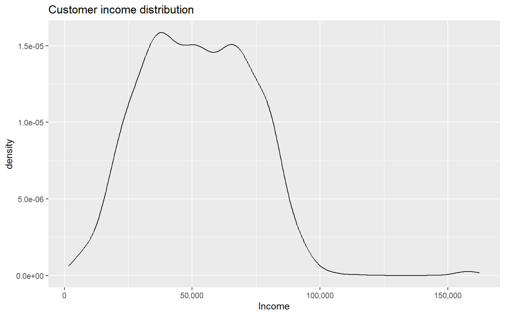

```r
# Shows that this customer can be eliminated
dataframe_processed <- dataframe_processed %>%
  filter(Income < 600000)

ggplot(dataframe_processed, aes(x = Income)) + geom_density() + scale_x_continuous(labels = label_comma()) + labs(title = "Customer income distribution", x = "Income")
```

### `Education` Variable

```r
# Check the observations in the variable
table(dataframe_processed$Education)
```

```
  2n Cycle      Basic Graduation     Master        PhD
       201         54       1126        370        485
```

```r
# duplicate data conversion (2n Cycle).

dataframe_processed <- dataframe_processed %>%
  mutate(Education = case_when(Education == "2n Cycle" ~ "Master",
                               TRUE ~ Education))

table(dataframe_processed$Education)
```

```
     Basic Graduation     Master        PhD
        54       1126        571        485
```

### `Total_Spending` Variable

```r
# Logic check

summary(dataframe_processed$Total_Spending)
```

```
   Min. 1st Qu.  Median    Mean 3rd Qu.    Max.
    5.0    69.0   396.5   606.0  1045.5  2525.0
```

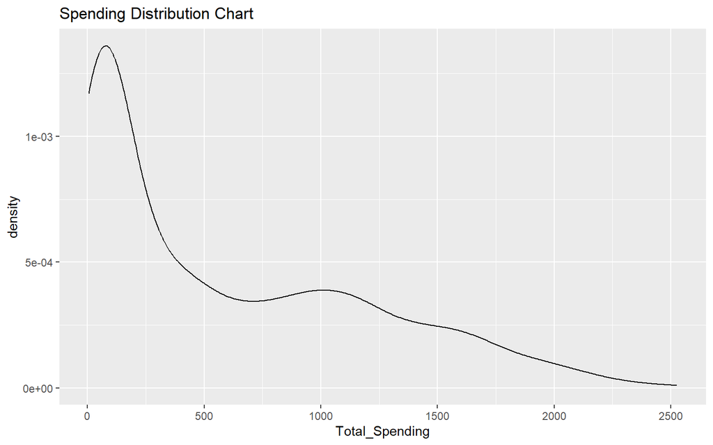

```r
# Distribution

ggplot(dataframe_processed, aes(x = Total_Spending)) + geom_density() + labs(title = "Spending Distribution Chart ", x = "Total_Spending")
```

Comment on the chart:

- The distribution is **clearly right-skewed**, where the main reason is that most customers have **low spending**, and only a small proportion of customers have high total spending.
- Comparing with the summary above, the mean value being significantly higher than the median confirms **the existence** of customers with very high spending, which skews the distribution to the right.

### `AOV` Variable

```r
# Logic check
summary(dataframe_processed$Average_Order_Value)
```

```
   Min. 1st Qu.  Median    Mean 3rd Qu.    Max.
   0.00   13.00   29.69   38.10   49.14 1679.00
```

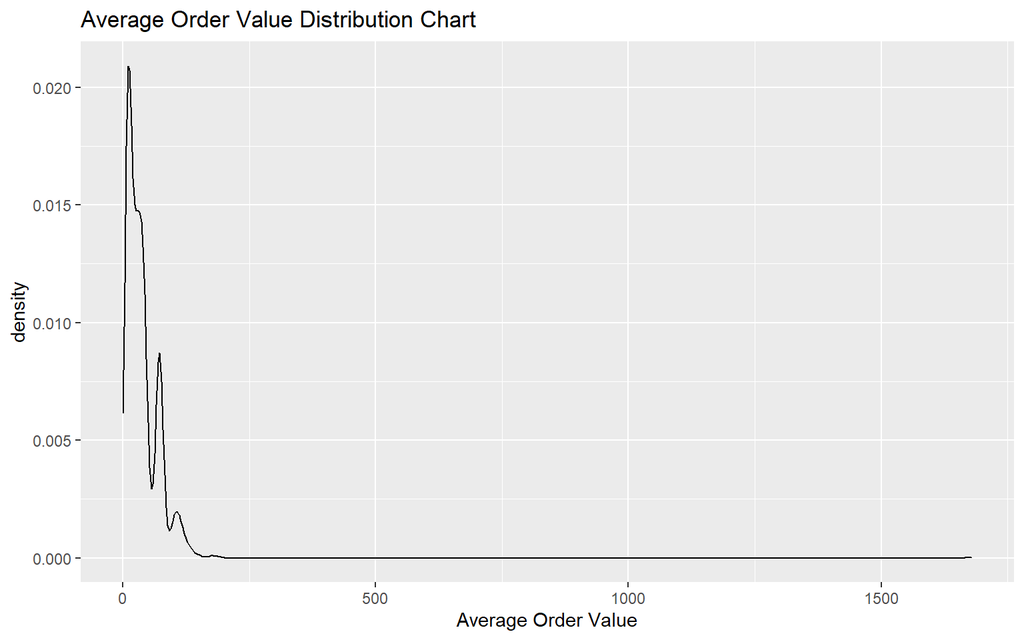

```r
# Distribution of the variable
ggplot(dataframe_processed, aes(x = Average_Order_Value)) + geom_density() + labs(title = "Average Order Value Distribution Chart", x = "Average Order Value")
```

Comments on the chart:

- The variable’s distribution is **strongly right-skewed** with some fairly large values. (Due to outliers)
- The outliers were kept because it is likely that these observations represent the group of high-value customers.

The univariate variables have been reviewed and processed to ensure that no values causing significant bias appear in the analysis step.

# **5. Analyze**

At this stage, we will conduct multivariate analysis (by creating tables and charts displayed with various factors) so that we can identify customer segments, which groups of customers respond well to upcoming marketing campaigns, and which products and sales channels are effective and need our attention.

## 1. Customer segment

### Customer group by total number of purchases.

Since there is an unusually high value (outlier), I will proceed to filter out that data. It doesn’t mean I am discarding the observation; it’s just that if that value remains, it will skew the charts and statistical indicators significantly compared to the rest of the data. (I will consider this customer separately).

The total number of customer purchases is calculated based on sales channels (web, store, catalog). To clarify, I group the customers as follows:

- Buy less than 10 times => “Low”.
- Buy more than 10 and less than 20 times => “Medium”.
- Buy more than 20 times => “High”.

```r
# Create a new variable for the dataframe

dataframe_Analyze <- dataframe_processed %>%
  mutate(Purchase_Frequency = case_when(Total_Purchase < 10 ~ "Low",
                                        Total_Purchase >= 10 & Total_Purchase < 20 ~ "Medium",
                                        Total_Purchase >= 20 ~ "High"),
         Purchase_Frequency = factor(Purchase_Frequency,
                                     levels = c("Low", "Medium","High")))
# Create Table

Table_1 <- dataframe_Analyze  %>%
  group_by(Purchase_Frequency) %>%
  summarise(Count = n(),
            Mean_AOV = mean(Average_Order_Value),
            Median_AOV = median(Average_Order_Value),
            SD_AOV = sd(Average_Order_Value))

kable(Table_1, caption = "Average revenue of customer groups by purchase frequency ")
```

Average revenue of customer groups by purchase frequency

| Purchase_Frequency | Count | Mean_AOV | Median_AOV | SD_AOV |
| --- | --- | --- | --- | --- |
| Low | 936 | 15.19712 | 11.5000 | 55.78126 |
| Medium | 829 | 54.31663 | 37.5625 | 30.99181 |
| High | 471 | 55.06851 | 46.7600 | 18.38238 |

**Data Observations**:

- The Medium group has an average order value (Mean_AOV) 3.5 times higher than the Low group (15.19712 vs 54.31663).
- However, there is no change in order value between the Medium and High groups.
- The Low group shows unpredictable spending behavior, as the `SD_AOV` indicator is quite high.

To better understand the data distribution and stability, I will visualize it using a box plot.

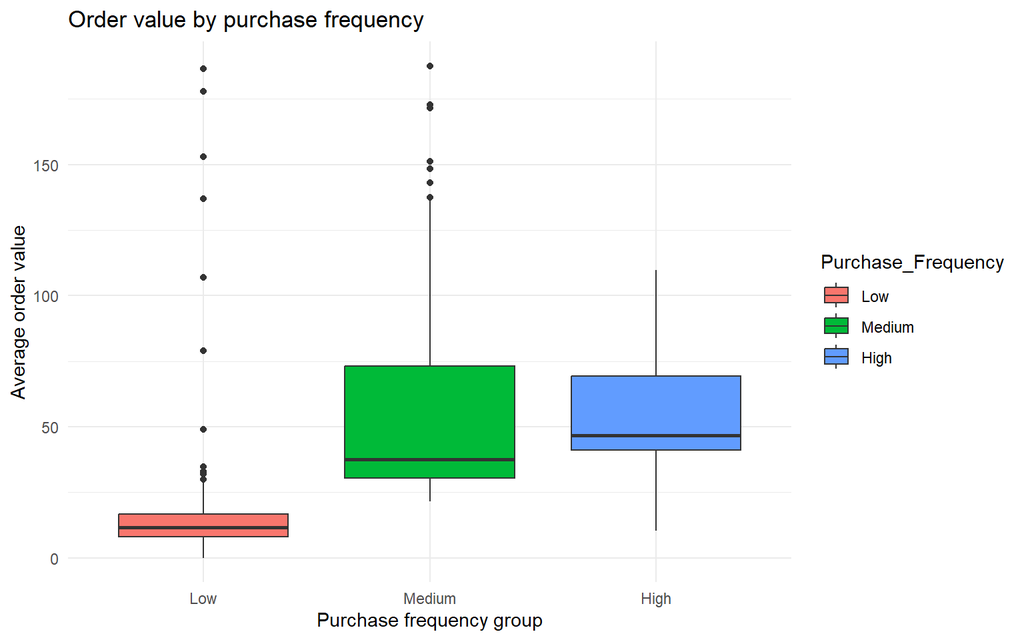

```r
dataframe_Analyze %>%
  filter(Average_Order_Value < 1500) %>%
  ggplot(aes(x = Purchase_Frequency, y = Average_Order_Value, fill = Purchase_Frequency)) +
  geom_boxplot() +
  theme_minimal() +
  labs(title = "Order value by purchase frequency",
       x = "Purchase frequency group",
       y = "Average order value")
```

**Insights**:

This may suggest that we can predict that frequent buyers will be more valuable in terms of revenue.

### Customer group using promotions.

The Deal_Dependency variable is calculated using the formula that is the ratio of the total number of promotion uses to the total number of purchases. That is, the higher the Deal_Dependency value, the more frequently customers use promotions, and conversely, as Deal_Dependency approaches 0, the number of promotion uses is quite low. To analyze this customer group, I will proceed with customer segmentation as follows:

- Deal_Dependency = 0 => Do not use deals.
- Deal_Dependency in the range (0, 0.2] => Moderate use of deals.
- Deal_Dependency in the range (0.2, 0.5] => Dependent on deal usage.
- Deal_Dependency greater than 0.5 => Addicted to using deals.

I based this allocation on descriptive statistics of the Deal_Dependency variable using quartiles, essentially relying on the variable’s distribution.

```r
# Create customer segmentation variables for the dataframe

dataframe_Analyze <- dataframe_processed %>%
  mutate(Deal_Group = case_when(Deal_Dependency == 0 ~ "Do not use",
                                Deal_Dependency > 0 & Deal_Dependency <= 0.2 ~ "Moderate",
                                Deal_Dependency > 0.2 & Deal_Dependency <= 0.5 ~ "Dependent",
                                Deal_Dependency > 0.5 ~ "Addicted to deals"),
        Deal_Group = factor(Deal_Group, levels = c("Do not use",
                                                   "Moderate",
                                                   "Dependent",
                                                   "Addicted to deals")))

# Table

Table_2 <- dataframe_Analyze %>%
  group_by(Deal_Group) %>%
  summarise(Count = n(),
            Average_Total_Spending = mean(Total_Spending),
            Median_Total_Spending = median(Total_Spending),
            Max_Total_Spending = max(Total_Spending))
kable(Table_2,caption = "Total spending of customers using deal")
```

Total spending of customers using deal

| Deal_Group | Count | Average_Total_Spending | Median_Total_Spending | Max_Total_Spending |
| --- | --- | --- | --- | --- |
| Do not use | 48 | 1183.6667 | 1251.5 | 2349 |
| Moderate | 1084 | 951.9723 | 968.5 | 2525 |
| Dependent | 961 | 231.5130 | 72.0 | 1826 |
| Addicted to deals | 143 | 305.9301 | 152.0 | 1730 |

**Insight:**

- Customers who do not use promotions are those with very high spending. Although the number of these customers is small compared to other customer groups, they are high-quality and generate significant revenue (Valuable customers).
- Meanwhile, customers who rely on deals (High - Very High) indicate that they care about promotions, but most of their orders are of low value (Price-sensitive).
- However, there are a few “Value-driven” customers among the groups that heavily rely on promotions (High - Very High). They have good financial capacity, but most of them wait for promotional periods to make purchases. The orders they place are also relatively high in value (based on Max_Total_Spending).

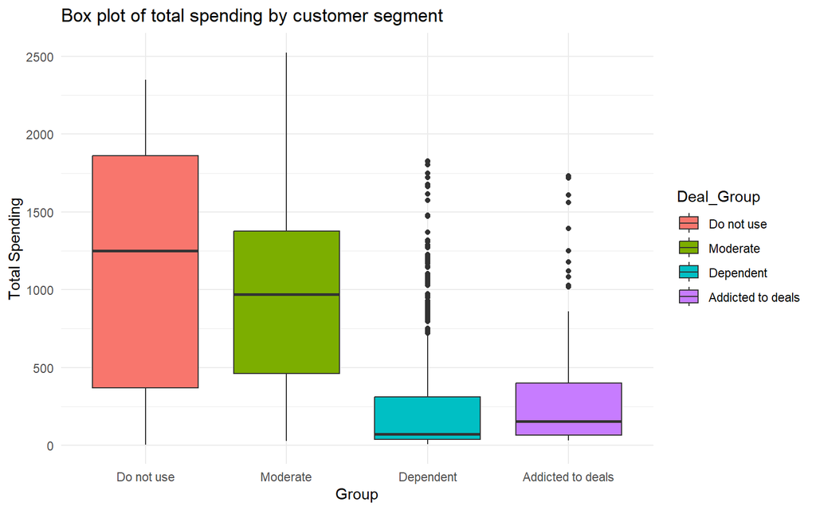

```r
  ggplot(dataframe_Analyze,aes(x = Deal_Group, y = Total_Spending, fill = Deal_Group)) +
  geom_boxplot() +
  theme_minimal() +
  labs(title = "Box plot of total spending by customer segment", x = "Group", y = "Total Spending")
```

**Insights**:

- The chart shows a strong negative correlation between deal dependency (`Deal_Depency`) and total spending (`Total_Spending`). Specifically, when customers rely on promotions, the average amount they spend on products decreases significantly.
- There are 2 groups of customers (those who do not use deals and those who use deals moderately) that have relatively high averages.
- The ‘deal-dependent’ or ‘deal-addicted’ column has the lowest average spending, with a number of customers (outliers) making high-value purchases while still relying on promotions. (These outliers need to be considered carefully as they might be ‘savvy’ customers who can afford high-value products but wait for major promotions to make purchases).

### Customer groups by education level and income.

```r
Table_3 <- dataframe_Analyze %>%
  group_by(Education) %>%
  summarise(Average_Total_Spending = mean(Total_Spending),
            Median_Total_Spending = median(Total_Spending),
            Max_Total_Spending = max(Total_Spending),
            SD_Total_Spending = sd(Total_Spending))

kable(Table_3, caption = "Total spending of customer groups by education level")
```

Total spending of customer groups by education level

| Education | Average_Total_Spending | Median_Total_Spending | Max_Total_Spending | SD_Total_Spending |
| --- | --- | --- | --- | --- |
| Basic | 81.7963 | 57.0 | 839 | 123.2273 |
| Graduation | 620.3943 | 414.5 | 2524 | 599.5614 |
| Master | 572.7968 | 326.0 | 2525 | 598.2431 |
| PhD | 669.9753 | 493.0 | 2440 | 614.4114 |

**Data Observations**:

- Regular customers have the lowest spending level (81.7973), which is quite far from the other groups.
- Customers with the other three education levels have higher average spending, but with a fairly high standard deviation, reflecting a large variation in spending (some spend a lot, others very little).

Therefore, education is not the only factor determining spending. To make this more visual, I created a scatter plot (with the y-axis representing total revenue, the x-axis representing income level, and the observations colored by education level).

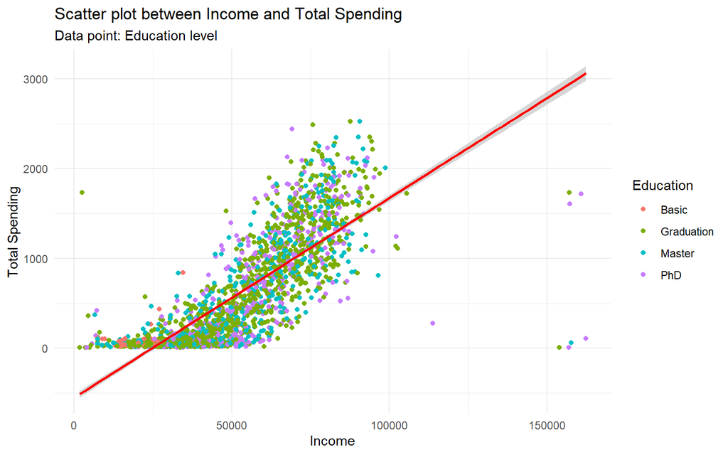

```r
ggplot(dataframe_processed, aes(x = Income, y = Total_Spending)) +
  geom_point(aes(color = Education)) +
  geom_smooth(method = "lm", color = "red") +
  labs(
    title = "Scatter plot between Income and Total Spending",
    subtitle = "Data point: Education level",
    x = "Income",
    y = "Total Spending"
  ) +
  theme_minimal()
```

**Insights**:

- The small light pink dots representing the Basic group indicate that their spending levels are quite low.
- Unlike the other three groups, the overlapping dispersion suggests that individuals with higher education (Graduation, Master, PhD) tend to have similar income and spending levels, indicating a strong positive correlation between Income and Total Spending regardless of degree.
- However, there are still some outliers with very high income > 150,000 but insignificant spending.

## 2. The response rate to customers’ marketing campaign.

Due to the previous issue, we implemented the strategy for the entire customer base at once, which led to a low acceptance rate. Through the process of analyzing each customer group based on behaviors and demographics, we found that the group that has a significant impact, with a strong and consistent linear relationship with the company’s revenue, is the Income group (higher income leads to higher spending). Therefore, we will focus on allocating customers based on Income.

I will create a Cross-Tabulation table combining the two most important factors: Income level and shopping behavior (Deal). It is distributed as follows:

Customers will be divided into 3 groups (High/medium/low salary - Deal hunters/regular buyers).

```r
# View quantile points

quantile(dataframe_processed$Deal_Dependency, probs = c(0.25, 0.5, 0.75, 0.9))
```

```
       25%        50%        75%        90%
0.08333333 0.20000000 0.33333333 0.50000000
```

```r
# => Choose 0.2 as the midpoint to divide the two classification values "Deal Hunter" and "Organic Buyer"
```

```r
# Create customer classification variables.
dataframe_Marketing <- dataframe_Analyze %>%
  mutate(Income_level = case_when(Income < 40000 ~ "Low Income",
                                  Income >= 40000 & Income < 80000 ~ "Mid Income",
                                  TRUE ~ "High Income"),
         Behavior_Type = case_when(Deal_Dependency > 0.2 ~ "Deal Hunter",
                                   TRUE ~ "Organic Buyer"),
        Income_level = factor(Income_level,level = c("Low Income",
                                                      "Mid Income",
                                                      "High Income")),
         Behavior_Type = factor(Behavior_Type, level = c("Organic Buyer","Deal Hunter")))

# Create a summary table for Marketing purposes.
Marketing_Table <- dataframe_Marketing %>%
  group_by(Income_level, Behavior_Type) %>%
  summarise(Count = n(),
            Average_Total_Spending = mean(Total_Spending),
            Response_Rate_Campaign = mean(Response) * 100,
            Total_Accept_Cmpt      = sum(AcceptedCmp1 +
                                     AcceptedCmp2 +
                                     AcceptedCmp3 +
                                     AcceptedCmp4 +
                                     AcceptedCmp5 )) %>%
  arrange(desc(Average_Total_Spending))


kable(Marketing_Table, caption = "Marketing Strategy: Income vs Behavior")
```

Marketing Strategy: Income vs Behavior

| Income_level | Behavior_Type | Count | Average_Total_Spending | Response_Rate_Campaign | Total_Accept_Cmpt |
| --- | --- | --- | --- | --- | --- |
| High Income | Deal Hunter | 6 | 1587.83333 | 0.00000 | 5 |
| High Income | Organic Buyer | 209 | 1512.81818 | 41.62679 | 253 |
| Mid Income | Organic Buyer | 802 | 941.53367 | 13.21696 | 257 |
| Mid Income | Deal Hunter | 488 | 421.18238 | 11.47541 | 86 |
| Low Income | Organic Buyer | 121 | 144.33884 | 14.04959 | 9 |
| Low Income | Deal Hunter | 610 | 83.88197 | 11.14754 | 56 |

**Insight**:

VIP Customer Group (high revenue value):

- (High income - Deal Hunter) this group makes purchases during promotional events but chooses very high-value items. However, their response to the company’s next campaign does not seem very promising.
- (High income - Organic Buyer) this is the most valuable customer group. Although the number is not very large (209 people), they have enormous spending power (1512.818) and notably, their response rate to this campaign seems to show they are very interested **(41.6%)**, the highest among the remaining groups.

Potential Group (Core):

- Potential customer group (Mid Income - Organic Buyer) This group has the highest spending among all groups, and also has a relatively high average spending. This is the group that brings the **most stable cash flow** with a large number of members (802 people) and fairly high spending (941), contributing the majority of the company’s total revenue.

Deal hunters group:

- Mainly focused on (Mid Income - Deal hunter, Low Income). Although the number of customers is quite significant, their average spending is lower than other groups (only about 1/2 to 1/10 of the Organic Buyer group).

A visual chart of customer groups and their response rates for the upcoming marketing campaign.

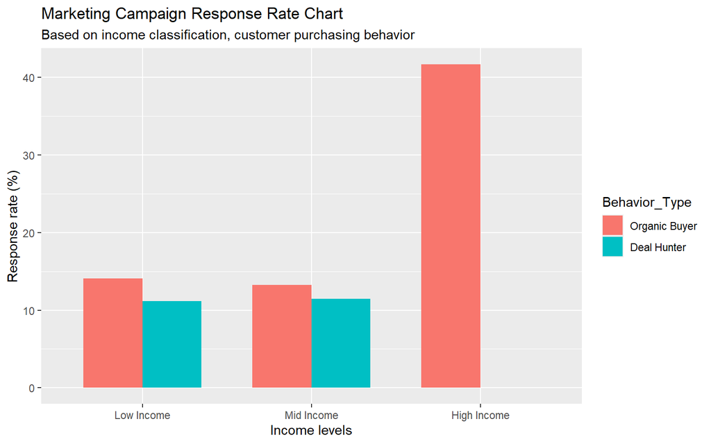

```r
# Create a dataset containing the aggregated average response rate by salary level and shopping behavior

plot_data <- dataframe_Marketing %>%
  group_by(Income_level, Behavior_Type) %>%
  summarise(Response_Rate_Campaign = mean(Response) * 100)

ggplot(plot_data, aes(x = Income_level,
                      y = Response_Rate_Campaign,
                      fill = Behavior_Type)) +
  geom_col(position = "dodge", width = 0.7) +
  labs(title = "Marketing Campaign Response Rate Chart",
       subtitle = "Based on income classification, customer purchasing behavior",
       x = "Income levels",
       y = "Response rate (%)")
```

## 3. Sales channels.

Below, I will analyze the three sales channels – Web, Catalog, and Store – based on different performance indicators (KPIs) to get a comprehensive picture.

**Note**: In this dataset, **there is no revenue breakdown for each channel**, only the total spending on items, so I can only compare the *Number of Purchases* and *conversion rate (Web)*.

First, I will perform descriptive statistics to understand the logic of the data:

```r
# 1. Create a summary table of order quantities by channel

channel_summary <- dataframe_Marketing %>%
  summarise(
    Store = sum(NumStorePurchases),
    Web = sum(NumWebPurchases),
    Catalog = sum(NumCatalogPurchases)
  ) %>%
  # Convert from wide format to long format to draw a Pie Chart
  pivot_longer(cols = everything(), names_to = "Channel", values_to = "Orders") %>%
  mutate(Percentage = round(Orders / sum(Orders) * 100, 1))

kable(channel_summary, caption = "Sales channels")
```

Sales channels

| Channel | Orders | Percentage |
| --- | --- | --- |
| Store | 12959 | 46.2 |
| Web | 9140 | 32.6 |
| Catalog | 5955 | 21.2 |

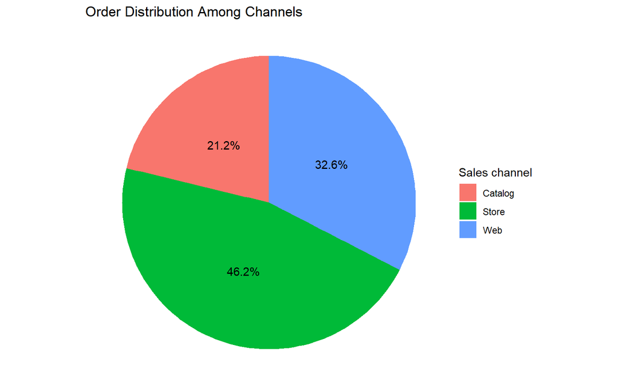

```r
# 2. Draw a pie chart
ggplot(channel_summary, aes(x = "", y = Orders, fill = Channel)) +
  geom_bar(stat = "identity", width = 1) +
  coord_polar("y", start = 0) +
  geom_text(aes(label = paste0(Percentage, "%")), position = position_stack(vjust = 0.5)) +
  labs(title = "Order Distribution Among Channels", fill = "Sales channel") +
  theme_void()
```

**Insight**:

- Regarding the sales channel that brings in the highest quantity for the company, it is the Store, accounting for 46.2%, indicating that the Store remains the company’s main sales channel.
- Next is the Website, accounting for 32.6%. To evaluate the effectiveness of this channel, we will calculate the website’s conversion rate.
- Finally, the Catalog, accounting for 21.2%, brings in the smallest number of orders (needs to be examined more closely).

### Website conversion rate

```r
# Website conversion efficiency

Web_Efficency <- dataframe_Marketing %>%
  summarise(Total_Visits = sum(NumWebVisitsMonth),
            Total_Purchase_Web = sum(NumWebPurchases),
            Conversion_Rate = sum(NumWebPurchases) / sum(NumWebVisitsMonth))
kable(Web_Efficency, caption = "Conversion rate")
```

Conversion rate

| Total_Visits | Total_Purchase_Web | Conversion_Rate |
| --- | --- | --- |
| 11893 | 9140 | 0.7685193 |

**Insight**:

- A conversion rate close to 1 indicates that the Website sales channel is performing very effectively, and more traffic should be driven to increase revenue.

## 4. Product distribution

To be more flexible, I proceeded to use the factor of Children as a variable that has a strong impact on shopping behavior in this dataset. I had previously created it in the Process section (Family_Status).

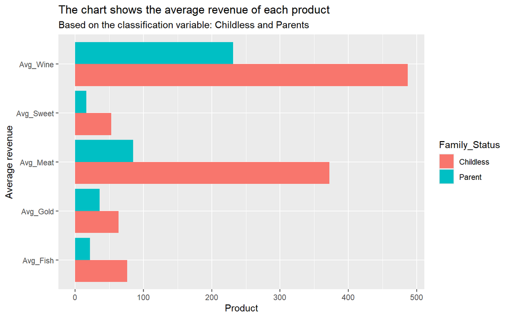

```r
# 1. Group by number of offspring

Product_Table <- dataframe_Analyze %>%
  group_by(Family_Status) %>%
  summarise(Avg_Wine = mean(MntWines),
            Avg_Meat = mean(MntMeatProducts),
            Avg_Fish = mean(MntFishProducts),
            Avg_Sweet = mean(MntSweetProducts),
            Avg_Gold = mean(MntGoldProds)) %>%
  # Convert from wide format to long format to plot the chart.

  pivot_longer(cols = starts_with("Avg"), names_to = "Product", values_to = "Spending")

# 2. Draw a comparison chart
ggplot(Product_Table, aes(x = Product, y = Spending, fill = Family_Status)) +
  geom_col(position = "dodge") +
  coord_flip() +
  labs(title = "The chart shows the average revenue of each product",
       subtitle = "Based on the classification variable: Childless and Parents",
       x = "Average revenue",
       y = "Product")
```

**Insight**:

- The chart clearly shows the impact of the variable (Children), indicating that people with children have a much lower average spending across all items compared to those without children.
- People without children tend to spend heavily on (Alcohol and Meat). The average revenue from these two products is significantly higher than the other products, and they can be considered the two main items.

# **6. Recommendation**

## Specific summary

Data shows that Income and Family Structure (children) are the two key factors influencing product purchasing behavior. Upcoming marketing strategies should focus on the High Income - Organic group to optimize effective marketing campaigns. At the same time, efforts should be made to strengthen Store/website sales channels by creating marketing and advertising programs. Additionally, the Meat and Alcohol product categories should be personalized to optimize for both audiences (with children and without children).